# DengAI: Predicting Disease Spread

Our main purpose is to predict the dengue fever case in two cities, San Juan and Iquitos. The dataset is taken from [DengAI competition hosted by DrivenData](https://www.drivendata.org/competitions/44/dengai-predicting-disease-spread/). We will build the prediction model with decision tree. The model will be evaluated using Mean Absolute Error (MAE).

# 1 Import Data

We will import the features and labels of our dataset.

```r
dengue_data <- read_csv("F:/UPH/Semester 9/Capstone/capstone2/dataset/dengue_features_train.csv")
dengue_labels_train <- read_csv("F:/UPH/Semester 9/Capstone/capstone2/dataset/dengue_labels_train.csv")
dengue_features_test <- read_csv("F:/UPH/Semester 9/Capstone/capstone2/dataset/dengue_features_test.csv")
submission_format <- read_csv("F:/UPH/Semester 9/Capstone/capstone2/dataset/submission_format.csv")
```

# 2 Data Pre-processing

## 2.1 Data Cleaning

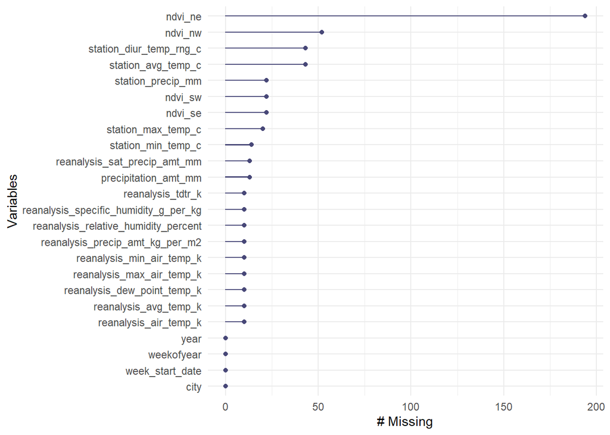

```r
gg_miss_var(dengue_data)
```

We can see that there are missing values in our training data. For column that has more than 25 missing values, we will drop it. Then, we will handle the rest with linear interpolation.

```r
Na_count <- data.frame(colSums(is.na(dengue_data)))
unnecessary_feature = rownames(Na_count)[Na_count$colSums.is.na.dengue_data..>25]

dengue_data  <- dengue_data[, -which(names(dengue_data) %in% unnecessary_feature)]
dengue_features_test  <- dengue_features_test[, -which(names(dengue_features_test) %in% unnecessary_feature)]

for(i in 5:length(dengue_data)){
  dengue_data[,i] <- na.approx(dengue_data[,i])
}
```

## 2.2 Mean Values of Data

```r
aggregated <- aggregate(dengue_data, by=list(city=dengue_data$city), FUN=mean)
aggregated <- as.data.frame(t(as.matrix(aggregated)))
colnames(aggregated) <- c("iq","sj")
knitr::kable(tail(aggregated, -5), "pipe", digits = 2)
```

|  | iq | sj |
| --- | --- | --- |
| ndvi_se | 0.2500028 | 0.1770898 |
| ndvi_sw | 0.2665365 | 0.1660884 |
| precipitation_amt_mm | 64.27231 | 35.38530 |
| reanalysis_air_temp_k | 297.8706 | 299.1573 |
| reanalysis_avg_temp_k | 299.1339 | 299.2705 |
| reanalysis_dew_point_temp_k | 295.4984 | 295.1035 |
| reanalysis_max_air_temp_k | 307.0717 | 301.3915 |
| reanalysis_min_air_temp_k | 292.8766 | 297.2972 |
| reanalysis_precip_amt_kg_per_m2 | 57.58914 | 30.42362 |
| reanalysis_relative_humidity_percent | 88.66039 | 78.56891 |
| reanalysis_sat_precip_amt_mm | 64.27231 | 35.38530 |
| reanalysis_specific_humidity_g_per_kg | 17.10179 | 16.54626 |
| reanalysis_tdtr_k | 9.196126 | 2.514225 |
| station_max_temp_c | 33.97702 | 31.59621 |
| station_min_temp_c | 21.20567 | 22.59380 |
| station_precip_mm | 62.01250 | 26.77885 |

The mean values of `precipitation_amt_mm`, `reanalysis_precip_amt_kg_per_m2`, `reanalysis_tdtr_k`, and `station_precip_mm` in `iq` and `sj` city are quite far apart. So, we should divide the data based on its city to get better result.

## 2.3 Correlation Matrix

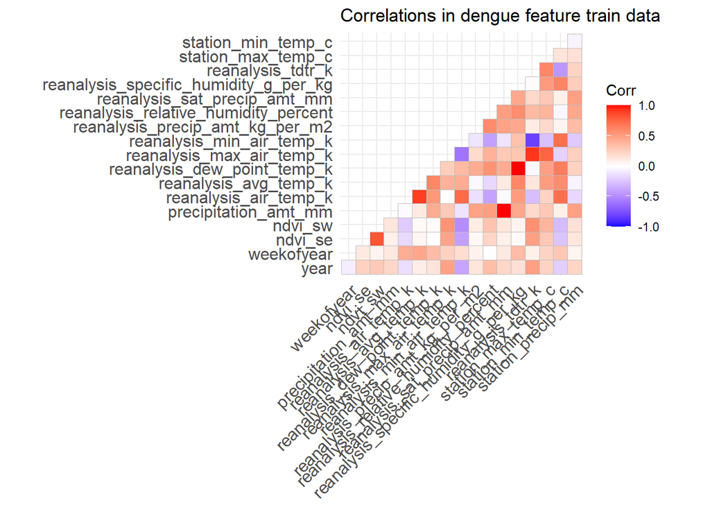

```r
#Get the numeric data only
num_dengue_data = subset(dengue_data, select = -c(city, week_start_date))

ggcorrplot(cor(num_dengue_data),
           type = "lower",
           title="Correlations in dengue feature train data")
```

```r
cormatrix <- cor(num_dengue_data)
cormatrix[upper.tri(cormatrix)] <- 0
diag(cormatrix) <- 0
highCorFeature <- num_dengue_data[,apply(cormatrix,2,function(x) any(x > 0.90))]
high_correlated_feature <- colnames(highCorFeature)
high_correlated_feature
```

```
## [1] "precipitation_amt_mm"        "reanalysis_air_temp_k"
## [3] "reanalysis_dew_point_temp_k" "reanalysis_max_air_temp_k"
```

```r
#Elimination of Redundant features
dengue_data  <- dengue_data[, -which(names(dengue_data) %in% high_correlated_feature)]
dengue_features_test  <- dengue_features_test[, -which(names(dengue_features_test) %in% high_correlated_feature)]
```

From the correlation matrix, we can see that there are pairs that have really high correlation. We will remove feature that has correlation value > 0.90 to decrease data redundancy.

## 2.4 Data Normalization

Now, we will check whether our data is normally distributed with normality test. We will apply Shappiro Wilk Test to all features, except `city`, `year`, `weekofyear`, and `week_start_date`. Here is the hypothesis for every feature.

$H_0$ : Data is normally distributed.

$H_1$ : Data is not normally distributed.

```r
feature <- c()
p_value <- c()

for(i in 5:dim(dengue_data)[2]){
  feature <- c(feature, colnames(dengue_data)[i])
  p_value <- c(p_value, shapiro.test(dengue_data[,i][[1]])$p.value)
}
shapiro_test_data <- data.frame(feature, p_value)

knitr::kable(shapiro_test_data, "pipe", digits = 18)
```

| feature | p_value |
| --- | --- |
| ndvi_se | 3.349610e-13 |
| ndvi_sw | 3.000000e-18 |
| reanalysis_avg_temp_k | 6.709919e-09 |
| reanalysis_min_air_temp_k | 0.000000e+00 |
| reanalysis_precip_amt_kg_per_m2 | 0.000000e+00 |
| reanalysis_relative_humidity_percent | 0.000000e+00 |
| reanalysis_sat_precip_amt_mm | 0.000000e+00 |
| reanalysis_specific_humidity_g_per_kg | 0.000000e+00 |
| reanalysis_tdtr_k | 0.000000e+00 |
| station_max_temp_c | 1.809609e-12 |
| station_min_temp_c | 1.880028e-12 |
| station_precip_mm | 0.000000e+00 |

We will use $\alpha = 0.05$ as our threshold of significance. Since the p-value of all features shown in the table is lower than 0.05, we can reject null hypothesis and accept alternative hypothesis. The data is not normally distributed so we will transform the data with z-score normalization method. However, before we do the normalization, we should transform the data into the same measure. All data with Kelvin measure will be converted to Celsius.

```r
#Transform columns with Kelvin temperature to Celsius
dengue_data[ , grepl("temp_k", names(dengue_data))] = dengue_data[ , grepl("temp_k", names(dengue_data))]-273.15

#rename column names that contain "temp_k" to "temp_c"
dengue_data = rename_with(dengue_data, ~ gsub("temp_k", "temp_c", .x,))

#Data Normalization
for(i in 5:length(dengue_data)){
  temp_mean <- colSums(dengue_data[,i])/count(dengue_data)
  temp_std <- var(dengue_data[,i])^(0.5)
  for(j in 1:1456){
    dengue_data[j,i] <- (dengue_data[j,i] - temp_mean)/temp_std
  }
}
```

## 2.5 Data Pre-processing for Test Dataset (Submission)

We will do data pre-processing to our test dataset with the same treatment as in our train dataset.

```r
#data imputation
for(i in 5:length(dengue_features_test)){
  dengue_features_test[,i] <- na.approx(dengue_features_test[,i])
}

#convert Kelvin to Celsius
dengue_features_test[ , grepl("temp_k", names(dengue_features_test))] = dengue_features_test[ , grepl("temp_k", names(dengue_features_test))]-273.15
dengue_features_test = rename_with(dengue_features_test, ~ gsub("temp_k", "temp_c", .x,))

#data normalization
for(i in 5:length(dengue_features_test)){
  temp_mean <- colSums(dengue_features_test[,i])/count(dengue_features_test)
  temp_std <- var(dengue_features_test[,i])^(0.5)
  for(j in 1:416){
    dengue_features_test[j,i] <- (dengue_features_test[j,i] - temp_mean)/temp_std
  }
}

dengue_features_test$weekofyear <- factor(dengue_features_test$weekofyear)
```

# 3 Feature Selection

We will do feature selection to know which feature that is important and not important for our prediction model using Boruta model. The `weekofyear` data also will be converted to categorical variable.

```r
dengue_data$weekofyear <- factor(dengue_data$weekofyear)

dengue_data <- cbind(dengue_data,dengue_labels_train[,4])

boruta_output<-Boruta(total_cases ~ ., data=dengue_data, doTrace=0, ntree=100)
boruta_output
```

```
## Boruta performed 99 iterations in 12.81818 secs.
##  15 attributes confirmed important: city, ndvi_se, ndvi_sw,
## reanalysis_avg_temp_c, reanalysis_min_air_temp_c and 10 more;
##  No attributes deemed unimportant.
##  1 tentative attributes left: reanalysis_sat_precip_amt_mm;
```

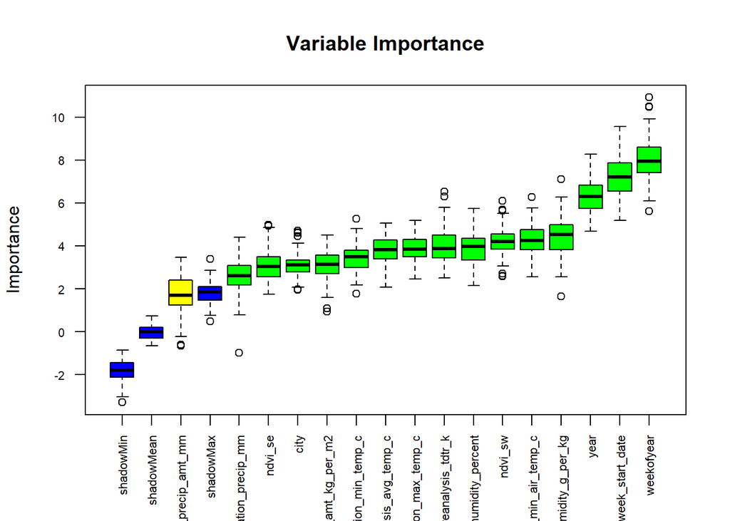

```r
boruta_signif <- getSelectedAttributes(boruta_output, withTentative = TRUE)
roughFixMod <- TentativeRoughFix(boruta_output)
boruta_signif <- getSelectedAttributes(roughFixMod)

imps <- attStats(roughFixMod)
imps2 = imps[imps$decision != 'Rejected', c('meanImp', 'decision')]
plot(boruta_output, cex.axis=.7, las=2, xlab="", main="Variable Importance")
```

```r
#remove not important feature
dengue_data <- dengue_data[ , -which(names(dengue_data) %in% c("reanalysis_sat_precip_amt_mm"))]
dengue_features_test  <- dengue_features_test[ , -which(names(dengue_features_test) %in% c("reanalysis_sat_precip_amt_mm"))]
```

# 4 Prediction Model with Decision Tree

We will build different model for each city so we will divide the data.

```r
normalized_dengue_sj <- subset(dengue_data, dengue_data$city == "sj")
normalized_dengue_iq <- subset(dengue_data, dengue_data$city == "iq")
normalized_test_sj <- subset(dengue_features_test, dengue_features_test$city == "sj")
normalized_test_iq <- subset(dengue_features_test, dengue_features_test$city == "iq")
```

## 4.1 Build decision tree model for `sj` city.

We will split our data to train dataset into training data and testing data with proportions of 80% and 20%, respectively. The purpose of this splitting is to build the model with training data and evaluate it with testing data. We will not split it randomly since this is a **timeseries** data.

```r
size = round(dim(normalized_dengue_sj)[1]*0.8)
train_data_sj <- normalized_dengue_sj[1:size,]
test_data_sj <- normalized_dengue_sj[(size+1):nrow(normalized_dengue_sj),]
```

```r
tree_sj <- rpart(total_cases ~ ., data = subset(train_data_sj, select =-c(city,year,week_start_date)), method = "anova")
tree_sj
```

```
## n= 749
##
## node), split, n, deviance, yval
##       * denotes terminal node
##
##  1) root 749 2265098.00  36.53538
##    2) weekofyear=1,2,3,4,5,6,7,8,9,10,11,12,13,14,15,16,17,18,19,20,21,22,23,24,25,26,27,28,29,30,31,51 462  278418.90  21.32251
##      4) weekofyear=6,7,8,9,10,11,12,13,14,15,16,17,18,19,20,21,22,23,24,25,26,27,28,29 348  108901.30  16.66667 *
##      5) weekofyear=1,2,3,4,5,30,31,51 114  138946.40  35.53509 *
##    3) weekofyear=32,33,34,35,36,37,38,39,40,41,42,43,44,45,46,47,48,49,50,52,53 287 1707641.00  61.02439
##      6) ndvi_sw< -0.1452499 178  334994.60  46.75843
##       12) reanalysis_specific_humidity_g_per_kg< 1.358375 171  237178.00  44.01170 *
##       13) reanalysis_specific_humidity_g_per_kg>=1.358375 7   65010.86 113.85710 *
##      7) ndvi_sw>=-0.1452499 109 1277262.00  84.32110
##       14) ndvi_sw>=-0.08344263 88  121811.30  45.09091 *
##       15) ndvi_sw< -0.08344263 21  452490.30 248.71430
##         30) ndvi_se>=-0.3641669 9   81522.00 107.00000 *
##         31) ndvi_se< -0.3641669 12   54662.00 355.00000 *
```

Now, we will plot the tree.

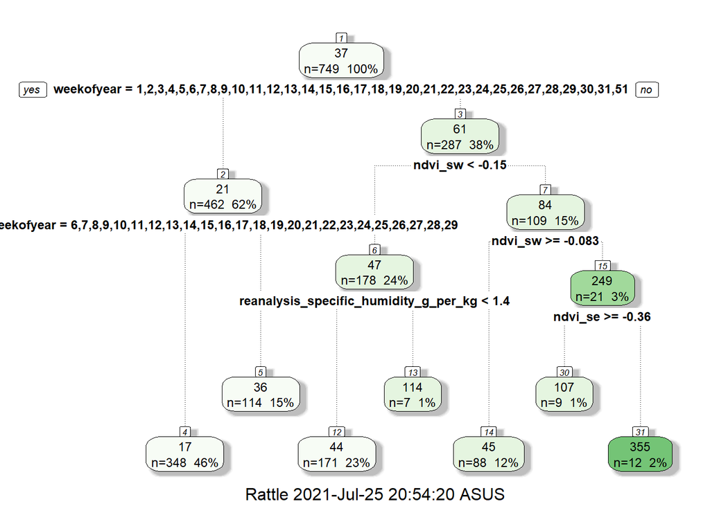

```r
fancyRpartPlot(tree_sj)
```

Here’s the model evaluation in predicting the testing data with Mean Absolute Error (MAE) metric. We got MAE of 21.925.

```r
pred_tree_sj <- predict(tree_sj, test_data_sj)
MAE(as.integer(pred_tree_sj), test_data_sj$total_cases)
```

```
## [1] 21.92513
```

We will plot the variable importance in our model.

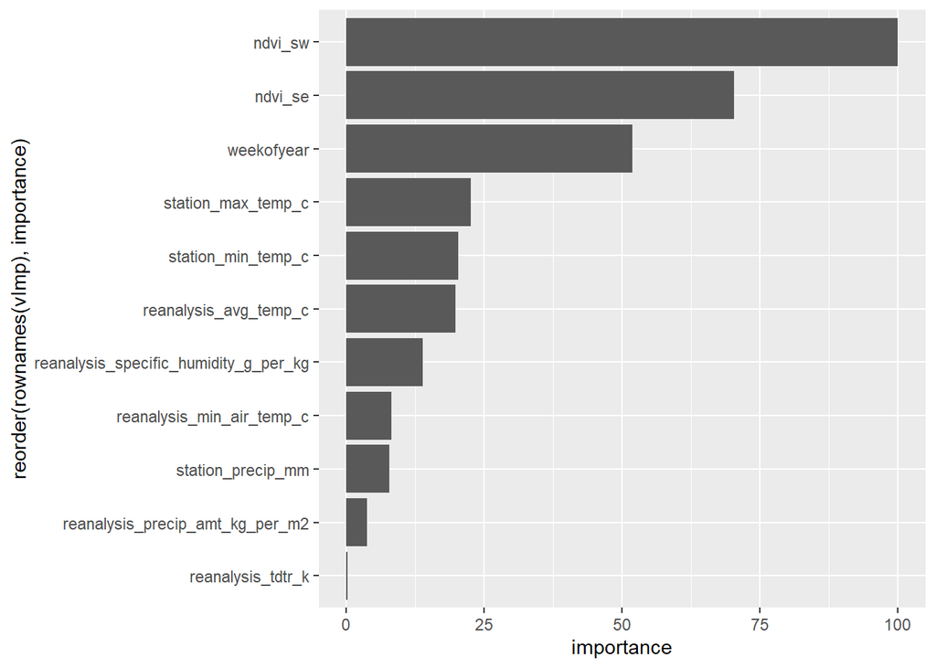

```r
vImp <- tree_sj$variable.importance
vImp <- vImp*100/max(vImp)
ind <- order(vImp)
vImp = data.frame(vImp)
names(vImp)[names(vImp)=="vImp"] = "importance"
ggplot(vImp,
       aes(x=reorder(rownames(vImp),importance), y=importance)) +
  geom_bar(stat = "identity") +
  coord_flip()
```

From the picture above, we can see that three most important variables are `ndvi_sw`, `ndvi_se`, and `weekofyear`.

Now, we will prune our tree to increase the model performance. We will choose Complexity Parameter (CP) from the smallest tree that have smallest cross validation error (xerror).

```r
printcp(tree_sj)
```

```
##
## Regression tree:
## rpart(formula = total_cases ~ ., data = subset(train_data_sj,
##     select = -c(city, year, week_start_date)), method = "anova")
##
## Variables actually used in tree construction:
## [1] ndvi_se                               ndvi_sw
## [3] reanalysis_specific_humidity_g_per_kg weekofyear
##
## Root node error: 2265098/749 = 3024.2
##
## n= 749
##
##         CP nsplit rel error  xerror    xstd
## 1 0.158548      0   1.00000 1.00088 0.18269
## 2 0.139644      3   0.52435 0.92933 0.16259
## 3 0.014483      4   0.38471 0.80650 0.13645
## 4 0.013497      5   0.37023 0.79850 0.12861
## 5 0.010000      6   0.35673 0.79908 0.12872
```

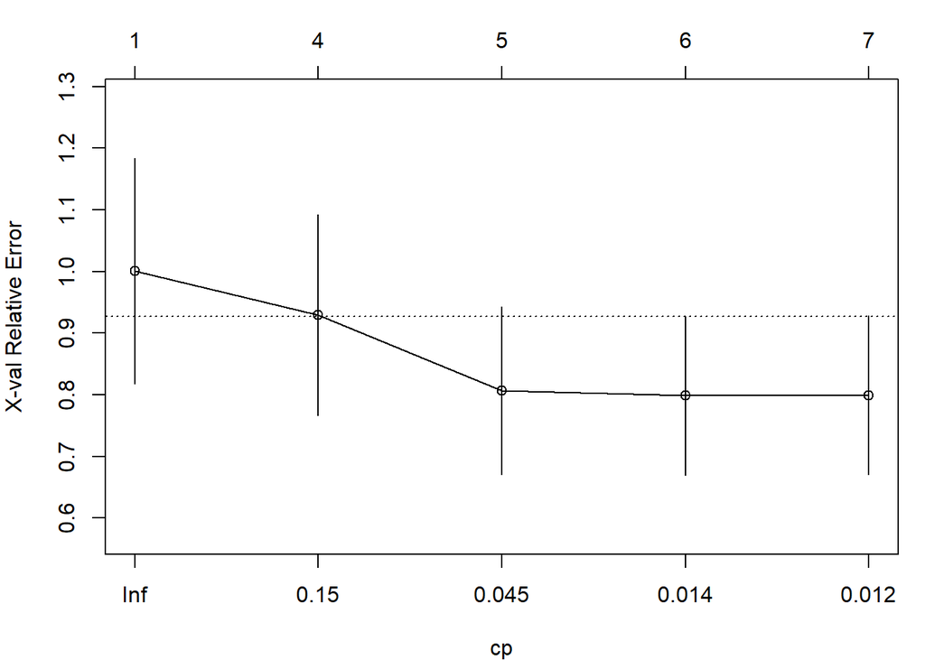

```r
par(mar=c(4,4,3,1))
plotcp(tree_sj)
```

```r
best.cp = tree_sj$cptable[which.min(tree_sj$cptable[,"xerror"]),"CP"]
print(best.cp)
```

```
## [1] 0.01349666
```

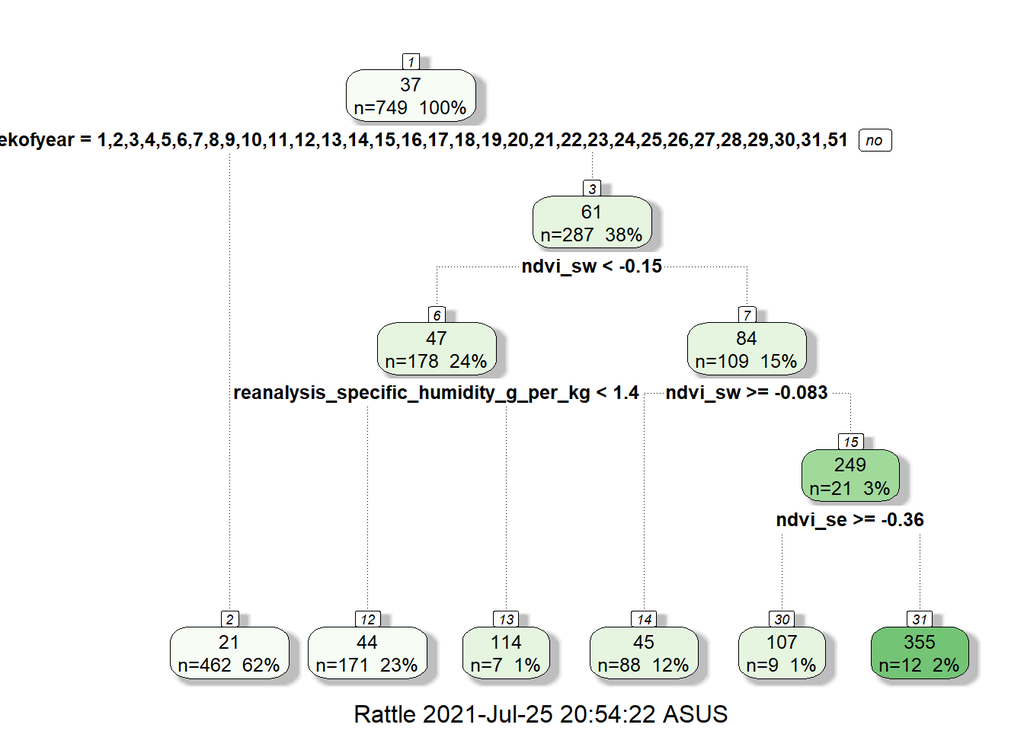

```r
tree2_sj <- prune(tree_sj, cp = best.cp)
fancyRpartPlot(tree2_sj)
```

Our pruned model resulted MAE of 21.74332. It performed better than the previous model.

```r
pred_tree_sj <- predict(tree2_sj, test_data_sj)
MAE(as.integer(pred_tree_sj), test_data_sj$total_cases)
```

```
## [1] 21.74332
```

## 4.2 Build decision tree model for `iq` city.

We will split our data into training data and testing data with proportions of 80% and 20%, respectively. We will not split it randomly since this is a **timeseries** data.

```r
size = round(dim(normalized_dengue_iq)[1]*0.8)
train_data_iq <- normalized_dengue_iq[1:size,]
test_data_iq <- normalized_dengue_iq[(size+1):nrow(normalized_dengue_iq),]
```

Build the decision tree model.

```r
tree_iq <- rpart(total_cases ~ ., data = subset(train_data_iq, select =-c(city, year, week_start_date)), method = "anova")
tree_iq
```

```
## n= 416
##
## node), split, n, deviance, yval
##       * denotes terminal node
##
##  1) root 416 46091.5400  7.076923
##    2) weekofyear=10,11,12,13,14,15,16,17,18,19,20,21,22,23,24,25,26,27,28,29,30,31,32,33,34,35,36,37,38,39,40,41,42,43,44,45,48,52 303  9154.1850  4.887789
##      4) reanalysis_specific_humidity_g_per_kg< 0.6222834 215  4906.9300  3.744186 *
##      5) reanalysis_specific_humidity_g_per_kg>=0.6222834 88  3279.0910  7.681818 *
##    3) weekofyear=1,2,3,4,5,6,7,8,9,46,47,49,50,51,53 113 31591.6800 12.946900
##      6) reanalysis_specific_humidity_g_per_kg< -0.3172993 19   842.5263  3.842105 *
##      7) reanalysis_specific_humidity_g_per_kg>=-0.3172993 94 28855.7400 14.787230
##       14) weekofyear=1,2,3,4,6,7,8,9,46,47,51,53 75 10351.5500 12.626670
##         28) reanalysis_avg_temp_c>=-0.6859656 58  5233.5860 10.724140
##           56) ndvi_se>=-0.008346977 43  2576.2790  8.604651 *
##           57) ndvi_se< -0.008346977 15  1910.4000 16.800000 *
##         29) reanalysis_avg_temp_c< -0.6859656 17  4191.7650 19.117650 *
##       15) weekofyear=5,49,50 19 16772.1100 23.315790 *
```

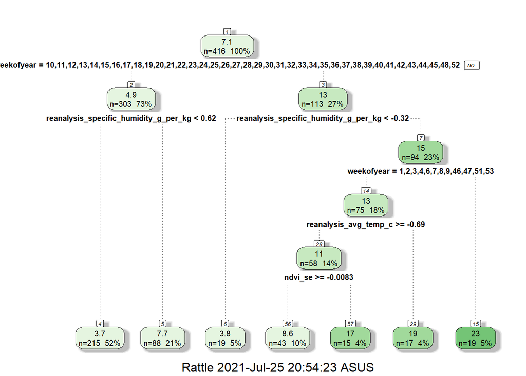

```r
fancyRpartPlot(tree_iq)
```

We got MAE of 6.817 in predicting test data.

```r
pred_tree_iq <- predict(tree_iq, test_data_iq)
MAE(as.integer(pred_tree_iq), test_data_iq$total_cases)
```

```
## [1] 6.817308
```

Now, we will plot the variable importance in our tree model.

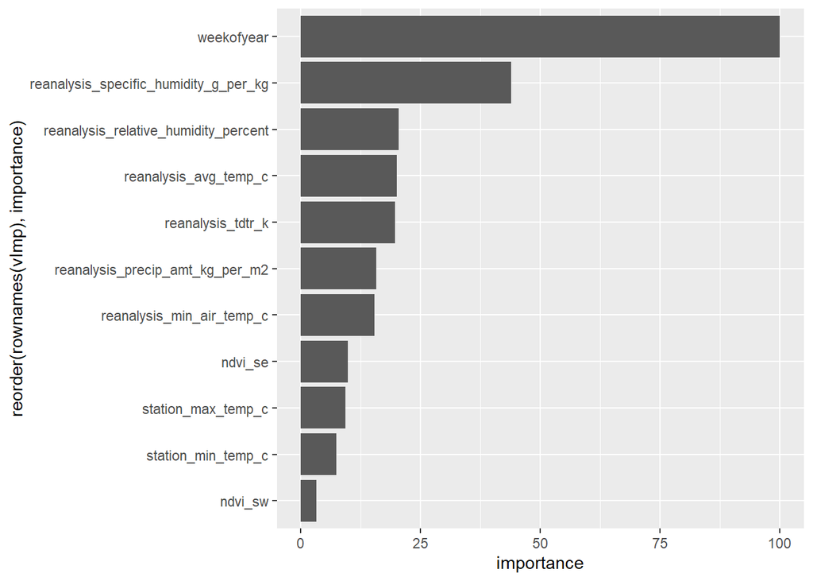

```r
vImp <- tree_iq$variable.importance
vImp <- vImp*100/max(vImp)
ind <- order(vImp)
vImp = data.frame(vImp)
names(vImp)[names(vImp)=="vImp"] = "importance"
ggplot(vImp,
       aes(x=reorder(rownames(vImp),importance), y=importance)) +
  geom_bar(stat = "identity") +
  coord_flip()
```

We will prune our tree by choosing the best CP.

```r
printcp(tree_iq)
```

```
##
## Regression tree:
## rpart(formula = total_cases ~ ., data = subset(train_data_iq,
##     select = -c(city, year, week_start_date)), method = "anova")
##
## Variables actually used in tree construction:
## [1] ndvi_se                               reanalysis_avg_temp_c
## [3] reanalysis_specific_humidity_g_per_kg weekofyear
##
## Root node error: 46092/416 = 110.8
##
## n= 416
##
##         CP nsplit rel error xerror    xstd
## 1 0.115979      0   1.00000 1.0041 0.29684
## 2 0.041079      1   0.88402 1.1074 0.27245
## 3 0.037579      2   0.84294 1.1608 0.27020
## 4 0.021005      3   0.80536 1.1983 0.28778
## 5 0.020095      4   0.78436 1.1886 0.28780
## 6 0.016205      5   0.76426 1.2147 0.29191
## 7 0.010000      6   0.74806 1.2587 0.30690
```

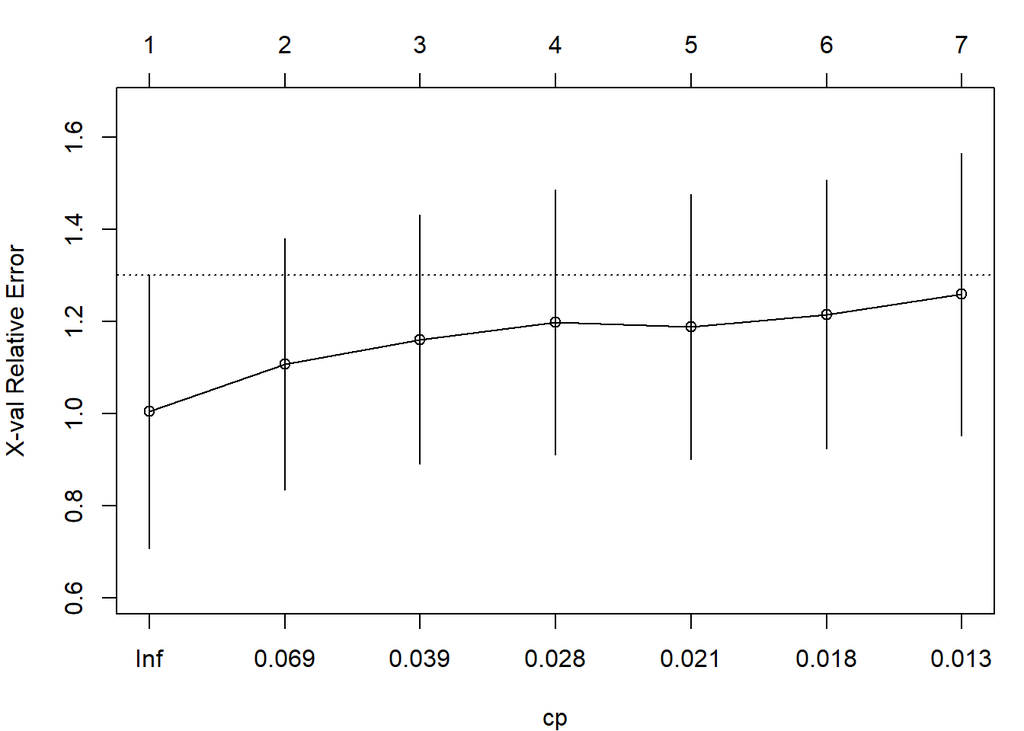

```r
par(mar=c(4,4,3,1))
plotcp(tree_iq)
```

```r
best.cp = tree_iq$cptable[which.min(tree_iq$cptable[,"xerror"]),"CP"]
```

The best CP is 0.115979.

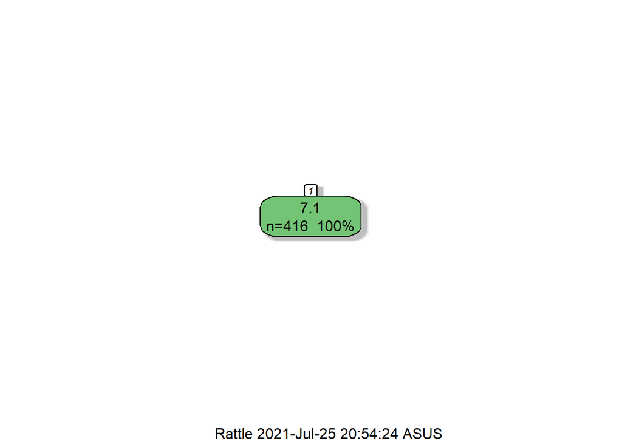

```r
tree2_iq <- prune(tree_iq, cp = best.cp)
fancyRpartPlot(tree2_iq)
```

The MAE from the pruned model is 7.269, which higher than the unpruned model. It seems that there is overfitting in our model.

```r
pred_tree_iq <- predict(tree2_iq, test_data_iq)
MAE(as.integer(pred_tree_iq), test_data_iq$total_cases)
```

```
## [1] 7.269231
```

# 5 Predict the submission data

We will try to predict the submission using the combination of our pruned and unpruned model. Then we will submit our prediction to the competition.

```r
#pruned decision tree for sj and unpruned decision tree for iq
pred_tree_sj <- predict(tree2_sj, normalized_test_sj)
pred_tree_iq <- predict(tree_iq, normalized_test_iq)
pred_tree_A <- c(pred_tree_sj, pred_tree_iq)

#decision tree with pruning for both cities.
pred_tree_sj <- predict(tree2_sj, normalized_test_sj)
pred_tree_iq <- predict(tree2_iq, normalized_test_iq)
pred_tree_B <- c(pred_tree_sj, pred_tree_iq)

#decision tree without pruning for both cities.
pred_tree_sj <- predict(tree_sj, normalized_test_sj)
pred_tree_iq <- predict(tree_iq, normalized_test_iq)
pred_tree_C <- c(pred_tree_sj, pred_tree_iq)
```

# 6 Result

From the table below, we can see that the best model is unpruned decision tree. It predicted the data with MAE of 26.1971. We are in 2024th place among 10674 competitors.

```r
sj_model <- c("Pruned tree", "Pruned tree", "Unpruned tree")
iq_model <- c("Unpruned tree", "Pruned tree", "Unpruned tree")
MAE <- c(26.2260, 26.4159, 26.1971)

result <- data.frame(sj_model, iq_model, MAE)

knitr::kable(result, "pipe", digits = 5)
```

| sj_model | iq_model | MAE |
| --- | --- | --- |
| Pruned tree | Unpruned tree | 26.2260 |
| Pruned tree | Pruned tree | 26.4159 |
| Unpruned tree | Unpruned tree | 26.1971 |